# Isaiah’s R package

Isaiah Pugh

2020-11-18

# Introduction

Congratulations for getting this far. To complete the evidence that you have made a working R package please answer the following by using the supplied rmd and upload the knitted html to CANVAS.

I will assume your package is called **isaiahpackage** and you have packaged and documented functions `myboot`, `myci`, `mycltp` and `mydbinom`.

# First function

Please place your first function in the r chunk in the following way:

Once you are ready please remove the option `eval = FALSE`

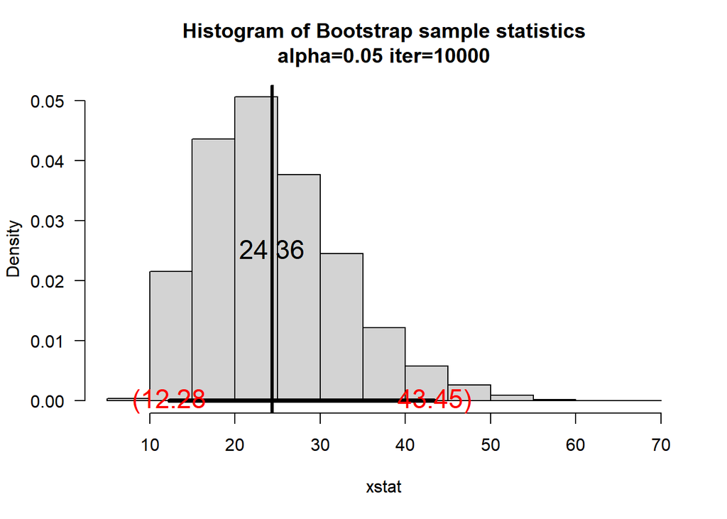

```r
ddt = read.csv("DDT.csv")
isaiahpackage::myboot2(x = ddt$DDT)
```

# Second function

Please place your second function in the r chunk in the following way:

Once you are ready please remove the option `eval = FALSE`

```r
x = rnorm(30,mean=10,sd=12)
isaiahpackage::myci(x)
```

```
## [1]  3.787519 12.469291
```

# Third function

Please place your third function in the r chunk in the following way:

Once you are ready please remove the option `eval = FALSE`

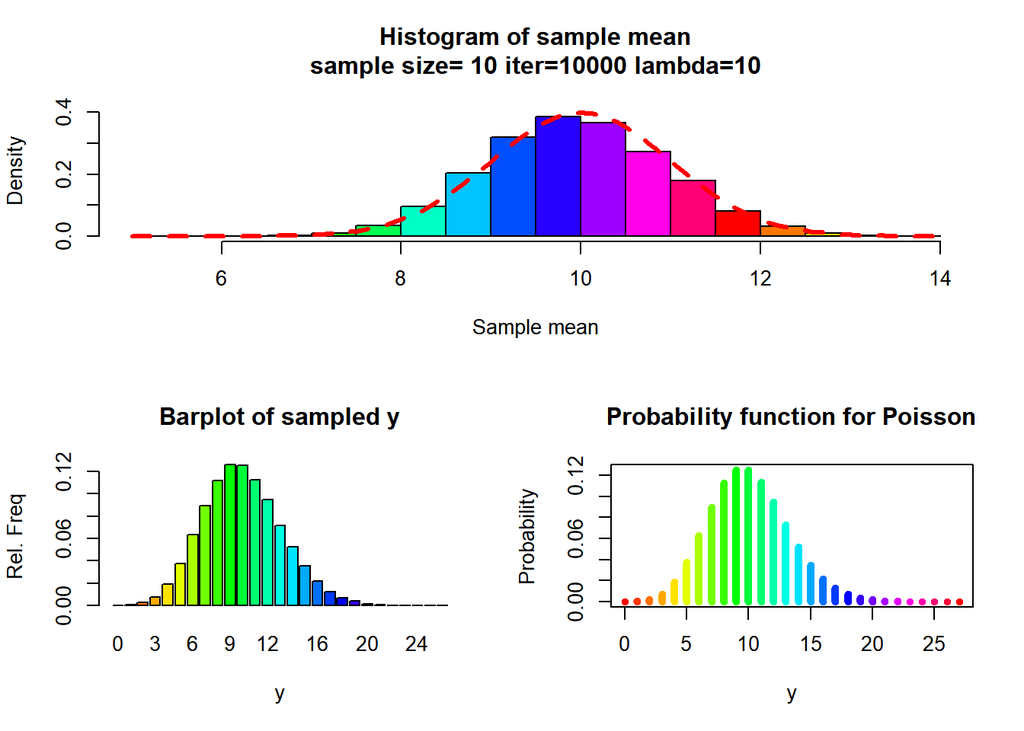

```r
isaiahpackage::mycltp(10,10000)
```

# Forth function

Please place your forth function in the r chunk in the following way:

Once you are ready please remove the option `eval = FALSE`

```r
isaiahpackage::mydbinom(1:10,100,0.5)
```

```
##  [1] 7.888609e-29 3.904861e-27 1.275588e-25 3.093301e-24 5.939138e-23
##  [6] 9.403635e-22 1.262774e-20 1.467975e-19 1.500596e-18 1.365543e-17
```

# The github repository

This is the address of my GITHUB repository: https://github.com/GvldenPharaoh/Rpackage.git

Replace this with your own address.